# Análisis de correspondencias

### Calidad de la representación

Si bien las dos dimensiones son capaces de retener alrededor de un $90\%$ de la información disponible, no todos las categorías están igualmente representadas (en términos de información aportada por las dimensiones) en ambas. Para medir la **calidad de la representación** de las filas en el mapa de factores empleados el $cos^2$ o cuadrado de las correlaciones. Esta medida, como sabemos, aporta el grado de asociación de filas o columnas con un eje determinado. Lo obtenemos del siguiente modo:

```r
round(filas$cos2,4)
```

```
            Dim 1  Dim 2  Dim 3  Dim 4
Trabaja    0.5227 0.4202 0.0435 0.0137
Domestico  0.5818 0.2002 0.2179 0.0001
Parado     0.0786 0.8415 0.0779 0.0020
Estudiante 0.7998 0.1931 0.0069 0.0002
Jubilado   0.8105 0.0014 0.1879 0.0002
```

Dado que la suma, por filas, de los valores siempre será igual a uno (indicando que la categoría de la fila está explicada en un $100\%$ por todas las dimensiones), cada celda de la salida anterior puede interpretarse como el efecto que la dimensión tiene en la explicación de la variable.

```r
apply(filas$cos2, 1, sum)
```

```
   Trabaja  Domestico     Parado Estudiante   Jubilado
         1          1          1          1          1
```

Así, la primera dimensión aporta un $81\%$ de la explicación de la posición de los jubilados en cuanto al voto, y un $80\%$ de la de los estudiantes. Lo podemos ver también mediante un gráfico de correlaciones.

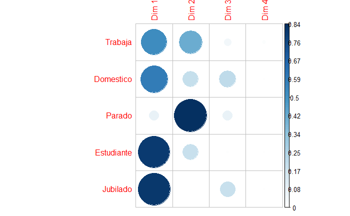

```r
corrplot(filas$cos2, is.corr = FALSE)
```

La función `fviz_cos2` nos ofrece la información agregada (para las dimensiones 1 y 2, por ejemplo, las más importantes) en forma de gráfico de barras:

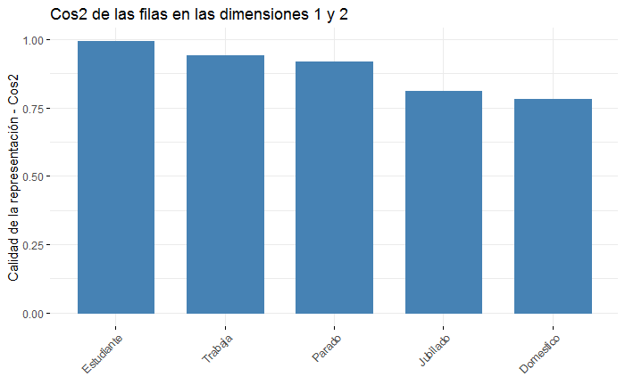

```r
fviz_cos2(votos.ca, choice="row", axes=1:2)+
        ggtitle("Cos2 de las filas en las dimensiones 1 y 2")+
        ylab("Calidad de la representación - Cos2")
```

Como muestra el gráfico, **todas** las categorías están correctamente representadas por las dos primeras dimensiones, recogiendo más de un $75\%$ de la información de la categoría que menos recogen.

Estos mismos análisis pueden realizarse para las columnas.

## Representación asimétrica de filas y columnas.

El problema más importante de la representación conjunta de filas y columnas que el *CA* realiza por defecto es que sólo puede medirse la relación que hay entre filas, por un lado, y entre columnas, por otro. Es decir, la conclusión ala que hemos llegado más arriba, al principio, no es correcta.

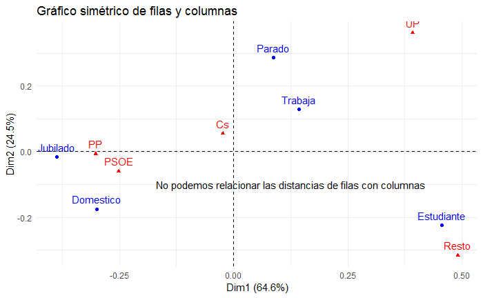

```r
fviz_ca_biplot(votos.ca)+
        ggtitle("Gráfico simétrico de filas y columnas")+
        annotate(geom="text", x=0.125, y=-0.1, label="No podemos relacionar las distancias de filas con columnas", color="black")+
        theme_minimal()
```

Para poder poder interpretar *correctamente* la distancia entre filas y columnas necesitamos proceder a la realización de un gráfico **asimétrico**, esto es, a representar las columnas en el espacio de las filas o viceversa. De acuerdo con Bendixen (2003) [Bendixen M. 2003, A Practical Guide to the Use of Correspondence Analysis in Marketing Research, Marketing Bulletin, 2003, 14, Technical Note 2.](http://marketing-bulletin.massey.ac.nz/V14/MB_V14_T2_Bendixen.pdf), para llevar a cabo el gráfico asimétrico, las filas (o columnas) se representarán a partir de sus coordenadas estándar, $S$, y los perfiles de las columnas (o filas) a partir de sus coordenadas principales, $P$. La relación entre unas y otras, siendo *eig* el autovalor del eje de representación, viene dada por

$$P=\sqrt{eig}\times S$$

La función `fviz_ca_biplot`permite añadir el argumento `map` para llevar a cabo tal representación, con las siguientes opciones:

- “rowprincipal” o “colprincipal” - gráficos asimétricos, con tanto las filas en coordenadas principales y columnas en estándar como lo contrario; las primeras se denominan *row-metric-preserving*, mientras que las segundas *column-metric-preserving*;
- “rowprincipal”: las columnas se representan en el espacio de las filas;
- “colprincipal”: las filas se representan en el espacio de columnas.
- “symbiplot” - filas y columnas se escalan para lograr que tengan varianzas iguales a los valores singulares, o raíces cuadradas de los autovalores; esto proporciona un gráfico simétrico **pero** no mantiene la métrica de filas o columnas;
- “rowgab” o “colgab”: mapas asimétricos propuestos por Gabriel y Odoroff (1990) (“Biplots in biomedical research”, Statistics in Medicine 9 (5): 469-485):
- “rowgab”: filas en coordenadas principales y columnas en coordenadas estándar, multiplicadas por su masa;
- “colgab”: columnas en coordenadas principales y filas en coordenadas estándar, multiplicadas por su masa.
- “rowgreen” o “colgreen”: los denominados gráficos de contribución, que muestran los más de mayor contribución, de acuerdo con Greenacre. Nota: puede descargarse el libro [“La práctica del análisis de correspondencias”](http://www.grupobbva.com/TLFU/dat/DE_2008_practica_analisis_correspondencias.pdf) del autor, por cortesía de la Fundación BBVA
- “rowgreen”: filas en coordenadas principales y columnas en estándar, multiplicadas por la raíz cuadrada de su masa;
- “colgreen”: columnas en coordenadas principales y filas en estándar, multiplicadas por la raíz cuadrada de su masa.

Lo podemos llevar a cabo de la siguiente manera:

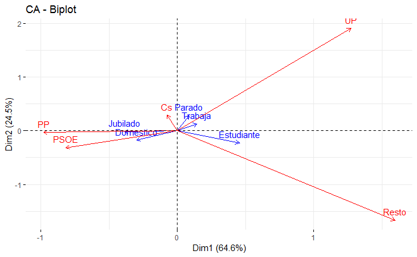

```r
fviz_ca_biplot(votos.ca, map ="rowprincipal", arrow = c(TRUE, TRUE))
```

Un ángulo muy agudo entre flechas de fila y columna indica una fuerte asociación entre ambas; para interpretar correctamente la distancia entre filas y columnas, debemos proyectar ortogonalmente la categoría de la fila sobre la flecha de la categoría de columna.

### Gráficos de contribución.

Un problema que suele darse en los gráficos de representación del *CA* es la identificación correcta de qué categorías son las que más contribuyen a la solución, situando aquellas de menor poder explicativo cerca del centro. En general se tiende a explicar la contribución de las filas a las dimensiones; para ello, se emplea la opción `map=colgreen`: en este caso, las columnas están representadas en coordenadas principales y las filas en coordenadas estándar multiplicadas por la raíz cuadrada de su masa. Para una fila dada, la raíz cuadrada de la nueva coordenada en en el eje *i* es, exactamente, la contribución de esta categoría de fila a la inercia del eje *i*. Al respecto, puede consultarse el *paper* de Greencare [aquí](https://www.tandfonline.com/doi/abs/10.1080/10618600.2012.702494?journalCode=ucgs20).

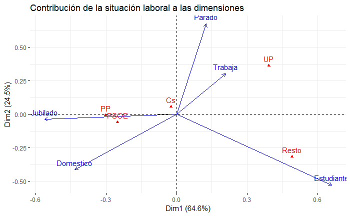

```r
fviz_ca_biplot(votos.ca, map ="colgreen",
               arrow = c(TRUE, FALSE))+
        ggtitle("Contribución de la situación laboral a las dimensiones")
```

Podemos ahora interpretar la contribución de los partidos a cada dimensión.

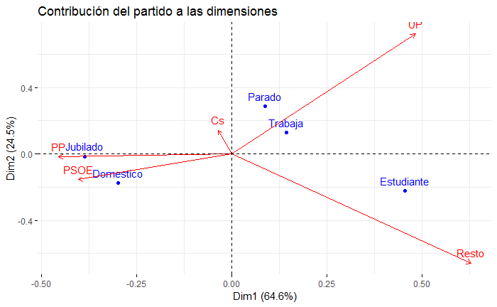

```r
fviz_ca_biplot(votos.ca, map ="rowgreen",
               arrow = c(FALSE, TRUE))+
        ggtitle("Contribución del partido a las dimensiones")
```